# Making Summary Tables for Publications Using `gtsummary`

```r
library(tidyverse)
library(gtsummary)
library(gt)
library(palmerpenguins)
library(flextable)
```

Lets peek at the documentation for `gtsummary`

https://www.danieldsjoberg.com/gtsummary/

It is very common (especially in biomedical literature) for the first table of the paper to summarize attributes of the participants in the study. This is a first look at whether the study could have some built-in demographic bias. We will use the built-in dataset `trial` from `gtsummary`.

```r
head(trial)
```

| trt | age | marker | stage | grade | response | death | ttdeath |
| --- | --- | --- | --- | --- | --- | --- | --- |
| Drug A | 23 | 0.160 | T1 | II | 0 | 0 | 24.00 |
| Drug B | 9 | 1.107 | T2 | I | 1 | 0 | 24.00 |
| Drug A | 31 | 0.277 | T1 | II | 0 | 0 | 24.00 |
| Drug A | NA | 2.067 | T3 | III | 1 | 1 | 17.64 |
| Drug A | 51 | 2.767 | T4 | III | 1 | 1 | 16.43 |
| Drug B | 39 | 0.613 | T4 | I | 0 | 1 | 15.64 |

Data are baseline characteristics of 200 cancer patients who received Drug A or Drug B with the outcome of tumor response to the treatment.

Variables:

- **trt** - Chemotherapy Treatment (Drug A or B)
- **age** - Age
- **marker** - Marker Level (ng/mL)
- **stage** - T Stage
- **grade** - Grade
- **response** - Tumor Response
- **death** - Patient Died
- **ttdeath** - Months to Death/Censor

```r
tbl_summary(trial, by = trt)
```

| **Characteristic** | **Drug A** N = 98<sup>1</sup> | **Drug B** N = 102<sup>1</sup> |
| --- | --- | --- |
| Age | 46 (37, 60) | 48 (39, 56) |
| Unknown | 7 | 4 |
| Marker Level (ng/mL) | 0.84 (0.23, 1.60) | 0.52 (0.18, 1.21) |
| Unknown | 6 | 4 |
| T Stage |  |  |
| T1 | 28 (29%) | 25 (25%) |
| T2 | 25 (26%) | 29 (28%) |
| T3 | 22 (22%) | 21 (21%) |
| T4 | 23 (23%) | 27 (26%) |
| Grade |  |  |
| I | 35 (36%) | 33 (32%) |
| II | 32 (33%) | 36 (35%) |
| III | 31 (32%) | 33 (32%) |
| Tumor Response | 28 (29%) | 33 (34%) |
| Unknown | 3 | 4 |
| Patient Died | 52 (53%) | 60 (59%) |
| Months to Death/Censor | 23.5 (17.4, 24.0) | 21.2 (14.5, 24.0) |

<sup>1</sup> Median (Q1, Q3); n (%)

```r
#uses all variables in a given table, so table should be relatively clean before summarizing
```

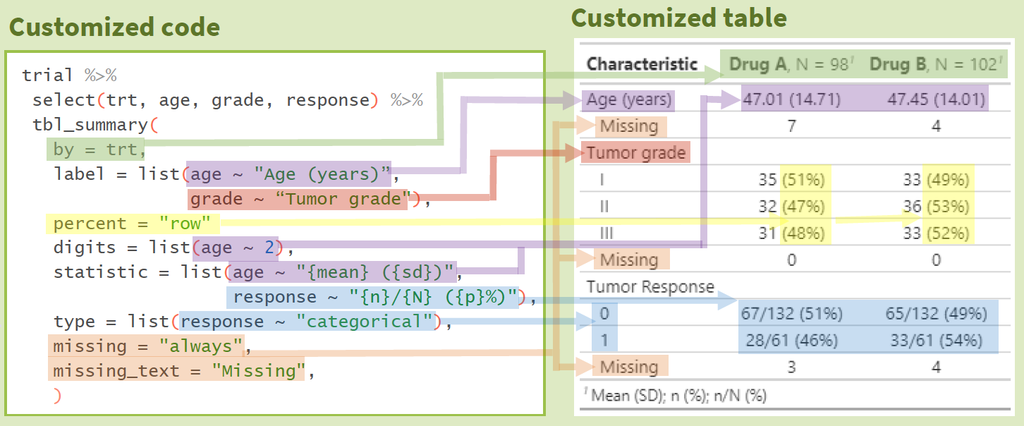

But the real value of `gtsummary` is that it will calculate statistics for comparison winthin/amomg groups. This might save you a lot of tedious and repetitive analyses.

## Example 1 t-test: Summarizing/Comparing Two Groups

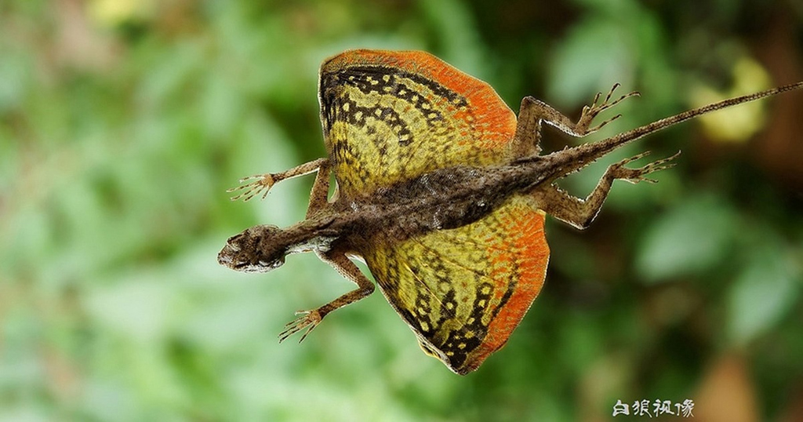

```r
draco_ecomorph <- read_csv("../data/draco_ecomorph.csv")
#..means look up one level for the 'data' folder
```

```r
glimpse(draco_ecomorph)
```

```
## Rows: 249
## Columns: 14
## $ id                     <chr> "P012_3", "P012_6", "P012_7", "P012_9", "P012_1…
## $ species                <chr> "bimaculatus", "bimaculatus", "bimaculatus", "b…
## $ sex                    <chr> "male", "male", "male", "male", "male", "male",…
## $ location               <chr> "Bohol", "Bohol", "Bohol", "Bohol", "Bohol", "B…
## $ snout_vent_length_mm   <dbl> 63, 68, 68, 68, 60, 67, 64, 66, 61, 65, 62, 77,…
## $ tail_length_mm         <dbl> 123, 123, 130, 148, 111, 128, 75, 122, 116, 104…
## $ fore_limb_length_mm    <dbl> 33.00, 33.57, 33.26, 33.01, 31.02, 36.26, 34.03…
## $ fore_toe_length_mm     <dbl> 10.19, 10.11, 11.63, 10.43, 11.57, 12.11, 10.70…
## $ hind_limb_length_mm    <dbl> 39.25, 38.57, 40.86, 39.92, 37.85, 39.78, 41.31…
## $ hind_toe_length_mm     <dbl> 15.06, 15.07, 15.94, 14.83, 13.75, 15.05, 13.76…
## $ perch_height_cm        <dbl> 230, 600, 580, 365, 364, 158, 180, 130, 164, 33…
## $ perch_circumference_cm <dbl> 62, 60, 190, 64, 52, 150, 225, 88, 108, 70, 82,…
## $ temperature_degreesC   <dbl> 25.3, 26.1, 29.3, 25.6, 27.4, 28.1, 25.6, 25.7,…
## $ season                 <chr> "spring", "spring", "spring", "spring", "spring…
```

```r
unique(draco_ecomorph$species)
```

```
##  [1] "bimaculatus"      "cornutus"         "formosus"         "heamatopogon"
##  [5] "melanopogon"      "obscurus"         "quinquefasciatus" "reticulatus"
##  [9] "spilopterus"      "sumatranus"
```

```r
unique(draco_ecomorph$location)
```

```
## [1] "Bohol"  "Bako"   "Niah"   "Malay"  "Kubah"  "Luzon"  "Borneo"
```

```r
# summarize the data; summary includes all species, so not that helpful yet
table1 <-
  draco_ecomorph %>%
  tbl_summary(
    by = sex,
    missing = "no", #gets rid of pesky NAs
    include = c(snout_vent_length_mm, tail_length_mm, fore_limb_length_mm)
  )

table1
```

| **Characteristic** | **female** N = 66<sup>1</sup> | **male** N = 183<sup>1</sup> |
| --- | --- | --- |
| snout_vent_length_mm | 76 (72, 84) | 75 (70, 79) |
| tail_length_mm | 121 (111, 138) | 116 (105, 141) |
| fore_limb_length_mm | 30.7 (27.7, 36.8) | 30.4 (26.3, 36.9) |

<sup>1</sup> Median (Q1, Q3)

Note that the default here is **median** and **IQR** for summary statistics; not what we might want. You can change the default behavior by setting a theme, or define manually (I prefer manually for complete control). Its more customary to use mean and SD (or SE) to summarize groups since we are most likely going to use parametric statistics for comparison. So after applying that theme, every new table will show **mean(SD)** for continuous variables — unless you explicitly override it in the `statistic=` argument.

```r
theme_gtsummary_mean_sd(set_theme = TRUE)
#Sets default summary statistics to mean and standard deviation in tbl_summary()
#Sets default continuous tests in add_p() to t-test and ANOVA
```

```r
#gtsummary works best with datasets without NA values, otherwise it attempts to report # of NAs (annoying)

table_Draco1 <- draco_ecomorph %>%
  filter(species == "bimaculatus") %>%
  # select variables to be summarized
  select(
    sex,
    snout_vent_length_mm,
    tail_length_mm,
    fore_limb_length_mm,
    fore_toe_length_mm,
    perch_height_cm
  ) %>%
  # retain specific variable used to define categories for comparison
  tbl_summary(
    by = sex,
    missing = "no",
  # remove missing values (NAs). "ifany" will include a missing values row in table.
    digits = all_continuous() ~ 1,
  # number of displayed digits for continuous variables
    statistic = list(all_continuous() ~ "{mean} ({sd})", #can use any character for parentheses
                     all_categorical() ~ "{n}"), #count obs. for categorical variables
    label = list(
      snout_vent_length_mm ~ "SVL (mm)",
      tail_length_mm ~ "Tail Length (mm)",
      fore_limb_length_mm ~ "Forelimb Length (mm)",
      fore_toe_length_mm ~ "Foretoe Length (mm)",
      perch_height_cm ~ "Perch Height (cm)"))

table_Draco1
```

| **Characteristic** | **female** N = 11<sup>1</sup> | **male** N = 41<sup>1</sup> |
| --- | --- | --- |
| SVL (mm) | 65.4 (7.4) | 71.1 (7.6) |
| Tail Length (mm) | 112.9 (13.4) | 114.6 (13.4) |
| Forelimb Length (mm) | 29.1 (3.4) | 29.3 (3.9) |
| Foretoe Length (mm) | 9.4 (1.2) | 10.3 (1.3) |
| Perch Height (cm) | 290.1 (136.2) | 403.4 (170.7) |

<sup>1</sup> Mean (SD)

Now lets pretty the table up a bit and make it a statistical comparison table.

```r
table_Draco1 <- table_Draco1 %>%
  add_p(test = all_continuous() ~ "t.test",
        pvalue_fun = ~ style_pvalue(.x, digits = 2)) %>% #number of sig. digits displayed for p-values
  modify_caption("Table 1. *Draco bimaculatus* Morphological Characteristics") %>%
  modify_fmt_fun(statistic ~ style_sigfig) %>% #adjusts sig .figs. for test stat column (t-value)
  modify_header(
    update = list(
      label ~ '',
      stat_1 ~ '**Female**',
      stat_2 ~ '**Male**',
      statistic ~ "**t-value**",
      p.value ~ '**P-value**'
    )
  )

table_Draco1
```

Table 1. *Draco bimaculatus* Morphological Characteristics

|  | **Female**<sup>1</sup> | **Male**<sup>1</sup> | **t-value**<sup>2</sup> | **P-value**<sup>2</sup> |
| --- | --- | --- | --- | --- |
| SVL (mm) | 65.4 (7.4) | 71.1 (7.6) | -2.2 | 0.039 |
| Tail Length (mm) | 112.9 (13.4) | 114.6 (13.4) | -0.38 | 0.71 |
| Forelimb Length (mm) | 29.1 (3.4) | 29.3 (3.9) | -0.23 | 0.82 |
| Foretoe Length (mm) | 9.4 (1.2) | 10.3 (1.3) | -2.2 | 0.040 |
| Perch Height (cm) | 290.1 (136.2) | 403.4 (170.7) | -2.3 | 0.032 |

<sup>1</sup> Mean (SD)  
<sup>2</sup> Welch Two Sample t-test

```r
show_header_names(table_Draco1)
```

```
## Column Name   Header          level*         N*         n*         p*
## label         ""                             52 <int>
## stat_1        "**Female**"    female <chr>   52 <int>   11 <int>   0.212 <dbl>
## stat_2        "**Male**"        male <chr>   52 <int>   41 <int>   0.788 <dbl>
## statistic     "**t-value**"                  52 <int>
## p.value       "**P-value**"                  52 <int>
```

```
## * These values may be dynamically placed into headers (and other locations).
## ℹ Review the `modify_header()` (`?gtsummary::modify()`) help for examples.
```

```r
#lets you preview code for changing header names and formatting
```

## Example 2 ANOVA Lizards: Summarizing/Comparing Three Groups

```r
#this function works best with datasets without NA values

table_Draco2 <- draco_ecomorph %>%
  select(species, sex, snout_vent_length_mm, perch_height_cm) %>% #retain variables used in summaries
  filter(species %in% c("bimaculatus", "cornutus", "melanopogon")) %>%
  tbl_summary(
    by = species,
    #every species gets its own column and summary stats
    missing = "no",
    # remove missing values (NAs). "ifany" will include a missing values row in table.
    digits = all_continuous() ~ 1,
    #number of displayed digits for continuous variables
    label = list(
      snout_vent_length_mm ~ "SVL (mm)",
      perch_height_cm ~ "Perch Height (cm)",
      sex ~ "Sex"
      #change column labels in table
    ),
    statistic = list(all_continuous() ~ "{mean} ({sd})", #can use any character for parentheses
                     all_categorical() ~ "{n}")  #count obs. for categorical variables
  ) %>%
  add_p(pvalue_fun = ~ style_pvalue(.x, digits = 2)) %>% #number of digits displayed for p-values
  modify_caption("Table 2. Lizard and Habitat Characteristics") %>%
  #modify_header(update = all_stat_cols() ~ "**{level}**") %>%  #headers to only contain species name
  #modify_footnote(all_stat_cols() ~ NA) %>% #squashes superscripts for the groups
  #modify_footnote(everything() ~ NA) %>%  #keeps-removes footnotes telling what tests were conducted
  modify_header(
    update = list(
      label ~ '',
      stat_1 ~ '*D. bimaculatus*',
      stat_2 ~ '*D. cornutus*',
      stat_3 ~ '*D. melanopogon*',
      p.value ~ 'P-value'
    )
  )

table_Draco2
```

Table 2. Lizard and Habitat Characteristics

|  | *D. bimaculatus*<sup>1</sup> | *D. cornutus*<sup>1</sup> | *D. melanopogon*<sup>1</sup> | P-value<sup>2</sup> |
| --- | --- | --- | --- | --- |
| Sex |  |  |  | 0.62 |
| female | 11 | 17 | 11 |  |
| male | 41 | 41 | 33 |  |
| SVL (mm) | 69.9 (7.9) | 76.4 (4.6) | 77.2 (4.6) | <0.001 |
| Perch Height (cm) | 379.4 (169.4) | 504.0 (185.9) | 335.1 (166.8) | <0.001 |

<sup>1</sup> n; Mean (SD)  
<sup>2</sup> Pearson’s Chi-squared test; One-way analysis of means (not assuming equal variances)

You can manually append data to an existing `gtsummary` table using the `modify_table_body()` function. Fist you need to make a data of the data you want to append. I’m using categories here because those are not a part of the summary calculations of the table.

```r
# A list (or named vector) of new values to append
custom_values <- tibble::tibble(
  variable = c("elevation", "activity"),
  label = c("Elevation", "Activity"),
  stat_1 = c("Low", "Nocturnal"),
  stat_2 = c("Medium", "Nocturnal"),
  stat_3 = c("High", "Diurnal")
)

custom_values
```

| variable | label | stat_1 | stat_2 | stat_3 |
| --- | --- | --- | --- | --- |
| elevation | Elevation | Low | Medium | High |
| activity | Activity | Nocturnal | Nocturnal | Diurnal |

```r
# Append the new rows to the bottom of the table
table_Draco3 <- table_Draco2 %>%
  modify_table_body(
    ~ bind_rows(.x, custom_values)
    # take the existing table (.x) and attach custom_values underneath it as new rows.
  )

table_Draco3
```

Table 2. Lizard and Habitat Characteristics

|  | *D. bimaculatus*<sup>1</sup> | *D. cornutus*<sup>1</sup> | *D. melanopogon*<sup>1</sup> | P-value<sup>2</sup> |
| --- | --- | --- | --- | --- |
| Sex |  |  |  | 0.62 |
| female | 11 | 17 | 11 |  |
| male | 41 | 41 | 33 |  |
| SVL (mm) | 69.9 (7.9) | 76.4 (4.6) | 77.2 (4.6) | <0.001 |
| Perch Height (cm) | 379.4 (169.4) | 504.0 (185.9) | 335.1 (166.8) | <0.001 |
| Elevation | Low | Medium | High |  |
| Activity | Nocturnal | Nocturnal | Diurnal |  |

<sup>1</sup> n; Mean (SD)  
<sup>2</sup> Pearson’s Chi-squared test; One-way analysis of means (not assuming equal variances)

```r
#Insert new rows before or after a specific index using `.before` or `.after`.

table_Draco4 <- table_Draco2 %>%
  modify_table_body(
    ~ add_row(.x, custom_values, .before = 1) #number is index number of row
    # take the existing table (.x) and attach custom_values before the 1st row.
  )

table_Draco4
```

Table 2. Lizard and Habitat Characteristics

|  | *D. bimaculatus*<sup>1</sup> | *D. cornutus*<sup>1</sup> | *D. melanopogon*<sup>1</sup> | P-value<sup>2</sup> |
| --- | --- | --- | --- | --- |
| Elevation | Low | Medium | High |  |
| Activity | Nocturnal | Nocturnal | Diurnal |  |
| Sex |  |  |  | 0.62 |
| female | 11 | 17 | 11 |  |
| male | 41 | 41 | 33 |  |
| SVL (mm) | 69.9 (7.9) | 76.4 (4.6) | 77.2 (4.6) | <0.001 |
| Perch Height (cm) | 379.4 (169.4) | 504.0 (185.9) | 335.1 (166.8) | <0.001 |

<sup>1</sup> n; Mean (SD)  
<sup>2</sup> Pearson’s Chi-squared test; One-way analysis of means (not assuming equal variances)

```r
table_Draco3 %>%
  as_flex_table() %>%
  flextable::save_as_docx(path = "../figs/table_Draco3.docx")
```

```r
#table_Draco3 %>%
  #as_gt() %>%   # convert to gt table for additional formatting options and saving
  #gt::gtsave(filename = "draco_ecomorph_table.pdf") #save file
```

**How `add_p()` decides which test to run**

Without specifying the test = argument, `gtsummary` **automatically chooses the test** based on the variable type and number of groups in `tbl_summary`(by =…)

Here’s what happens internally:

[output not shown]

If you want a traditional parametric one-way test (e.g. ANOVA for 3 or more groups) use: `add_p`(test = ~“oneway.test”)

**Advanced Customization**

It’s natural a `gtsummary` user would want to customize the aestheticsof the table with one or more of the many `gt` functions available. `gt` is the table equivalent of `ggplot2`; very powerful and you can change/customize just about everything.

Every function in `gt` is available to use with a `gtsummary` object.

1. Create a `gtsummary` table.
2. Convert the table to a `gt` object with the `as_gt()` function.
3. Continue formatting as a `gt` table with any `gt` function.

## Example 3 ANOVA Penguins

```r
table_penguins <- penguins %>%
  select(species, sex, bill_length_mm, bill_depth_mm, flipper_length_mm, body_mass_g) %>% #retain variables used in summaries
  tbl_summary(by = species,
              missing = "no", # remove missing values (NAs). "ifany" will include a missing values row in table.
              digits = all_continuous() ~ 1, #number of displayed digits for continuous variables
              label = list(bill_length_mm ~ "Bill Length (mm)", #change column labels in table
                           bill_depth_mm ~ "Bill Depth (mm)",
                           flipper_length_mm ~ "Flipper Length (mm)",
                           body_mass_g ~ "Body Mass (g)",
                           sex ~ "Sex"),
              statistic = list(all_continuous() ~ "{mean} ({sd})", #can use any character for parentheses
                               all_categorical() ~ "{n}")) %>% #count obs. for categorical variables
  add_p(pvalue_fun = ~style_pvalue(.x, digits = 2)) %>% #number of digits displayed for p-values
  modify_caption("Table 3. Palmer Penguin Morphometrics") %>%
  modify_header(update = all_stat_cols() ~ "**{level}**") #headers to only contain species name

table_penguins
```

Table 3. Palmer Penguin Morphometrics

| **Characteristic** | **Adelie**<sup>1</sup> | **Chinstrap**<sup>1</sup> | **Gentoo**<sup>1</sup> | **p-value**<sup>2</sup> |
| --- | --- | --- | --- | --- |
| Sex |  |  |  | 0.98 |
| female | 73 | 34 | 58 |  |
| male | 73 | 34 | 61 |  |
| Bill Length (mm) | 38.8 (2.7) | 48.8 (3.3) | 47.5 (3.1) | <0.001 |
| Bill Depth (mm) | 18.3 (1.2) | 18.4 (1.1) | 15.0 (1.0) | <0.001 |
| Flipper Length (mm) | 190.0 (6.5) | 195.8 (7.1) | 217.2 (6.5) | <0.001 |
| Body Mass (g) | 3,700.7 (458.6) | 3,733.1 (384.3) | 5,076.0 (504.1) | <0.001 |

<sup>1</sup> n; Mean (SD)  
<sup>2</sup> Pearson’s Chi-squared test; One-way analysis of means (not assuming equal variances)

Convert table to a `gt` object for more formatting options.

```r
table_penguins %>%
  as_gt() %>%
  opt_stylize(style = 6, color = 'gray', add_row_striping = TRUE) %>%
  tab_header(title = md("**Penguin Measurements**")) %>%
  opt_align_table_header(align = "left") %>%
  tab_options(heading.align = "left") %>%
  tab_source_note(source_note = md("Source: Gorman KB, Williams TD, Fraser WR (2014). Ecological sexual dimorphism and environmental variability within a community of Antarctic penguins (genus *Pygoscelis*). PLoS ONE 9(3):e90081. https://doi.org/10.1371/journal.pone.0090081."))
```

Table 3. Palmer Penguin Morphometrics

**Penguin Measurements**

| **Characteristic** | **Adelie**<sup>1</sup> | **Chinstrap**<sup>1</sup> | **Gentoo**<sup>1</sup> | **p-value**<sup>2</sup> |
| --- | --- | --- | --- | --- |
| Sex |  |  |  | 0.98 |
| female | 73 | 34 | 58 |  |
| male | 73 | 34 | 61 |  |
| Bill Length (mm) | 38.8 (2.7) | 48.8 (3.3) | 47.5 (3.1) | <0.001 |
| Bill Depth (mm) | 18.3 (1.2) | 18.4 (1.1) | 15.0 (1.0) | <0.001 |
| Flipper Length (mm) | 190.0 (6.5) | 195.8 (7.1) | 217.2 (6.5) | <0.001 |
| Body Mass (g) | 3,700.7 (458.6) | 3,733.1 (384.3) | 5,076.0 (504.1) | <0.001 |

Source: Gorman KB, Williams TD, Fraser WR (2014). Ecological sexual dimorphism and environmental variability within a community of Antarctic penguins (genus *Pygoscelis*). PLoS ONE 9(3):e90081. https://doi.org/10.1371/journal.pone.0090081.  
<sup>1</sup> n; Mean (SD)  
<sup>2</sup> Pearson’s Chi-squared test; One-way analysis of means (not assuming equal variances)

```r
#heading.align controls the horizontal alignment of both title and subtitle.
#opt_align_table_header(align = "left") only affects column headers, not the table title.
```

## Example 4 ANCOVA Lizards

```r
draco_bimaculatus <- draco_ecomorph %>%
  filter(species == "bimaculatus") #get one species to work with
```

```r
#ANCOVA measurements adjusted for SVL covariate

ex4 <- draco_bimaculatus%>%
  select(tail_length_mm, snout_vent_length_mm, fore_limb_length_mm, hind_limb_length_mm, sex)%>%
  tbl_summary(by=sex,
              #statistic=list(all_continuous()~"{mean}({sd})"),
              #missing="no",
              digits = all_continuous() ~ 1,
              include=c(tail_length_mm, fore_limb_length_mm, hind_limb_length_mm)) %>%
add_difference(
    adj.vars = c(snout_vent_length_mm), #this line turns it from an ANOVA to an ANCOVA table (magic)
    # adjust the variables being compared between sexes by the snout_vent_length variable
    pvalue_fun = ~style_pvalue(.x, digits = 2)  # control p-value rounding here
  )

ex4
```

| **Characteristic** | **female** N = 11<sup>1</sup> | **male** N = 41<sup>1</sup> | **Adjusted Difference**<sup>2</sup> | **95% CI**<sup>2,3</sup> | **p-value**<sup>2</sup> |
| --- | --- | --- | --- | --- | --- |
| tail_length_mm | 112.9 (13.4) | 114.6 (13.4) | 0.17 | -9.3, 9.7 | 0.97 |
| fore_limb_length_mm | 29.1 (3.4) | 29.3 (3.9) | -0.78 | -3.5, 1.9 | 0.56 |
| hind_limb_length_mm | 34.3 (5.5) | 34.6 (4.9) | -1.3 | -4.8, 2.2 | 0.47 |

<sup>1</sup> Mean (SD)  
<sup>2</sup> ANCOVA  
<sup>3</sup> CI = Confidence Interval

```r
ex4 %>%
  as_flex_table() %>%
  flextable::save_as_docx(path = "../figs/ex4_flextable.docx")
```

```r
#if you include SVL as a variable in the list to be analyzed by gtsummary, it does a t-test on SVL, not ANCOVA
t.test(snout_vent_length_mm~sex, data=draco_bimaculatus)
```

```
##
##  Welch Two Sample t-test
##
## data:  snout_vent_length_mm by sex
## t = -2.2456, df = 16.122, p-value = 0.03909
## alternative hypothesis: true difference in means between group female and group male is not equal to 0
## 95 percent confidence interval:
##  -11.0763763  -0.3222933
## sample estimates:
## mean in group female   mean in group male
##             65.41091             71.11024
```

SVL variable (snout_vent_length_mm) is excluded from table above; if you wanted to include it, you would need to explain the table in more depth because it has both a single t-test for SVL (raw means) and a bunch on ANCOVAs for the other variables (presenting marginal means).

```r
model_1 <- lm(tail_length_mm ~ snout_vent_length_mm + sex, data=draco_bimaculatus)
#notice this is a parallel slopes model (How can you tell?)
summary(model_1)
```

```
##
## Call:
## lm(formula = tail_length_mm ~ snout_vent_length_mm + sex, data = draco_bimaculatus)
##
## Residuals:
##     Min      1Q  Median      3Q     Max
## -37.265  -8.599  -1.929   8.571  34.402
##
## Coefficients:
##                      Estimate Std. Error t value Pr(>|t|)
## (Intercept)           91.1163    16.7151   5.451 1.62e-06 ***
## snout_vent_length_mm   0.3332     0.2481   1.343    0.185
## sexmale               -0.1738     4.7351  -0.037    0.971
## ---
## Signif. codes:  0 '***' 0.001 '**' 0.01 '*' 0.05 '.' 0.1 ' ' 1
##
## Residual standard error: 13.31 on 49 degrees of freedom
## Multiple R-squared:  0.03826,    Adjusted R-squared:  -0.000991
## F-statistic: 0.9748 on 2 and 49 DF,  p-value: 0.3845
```

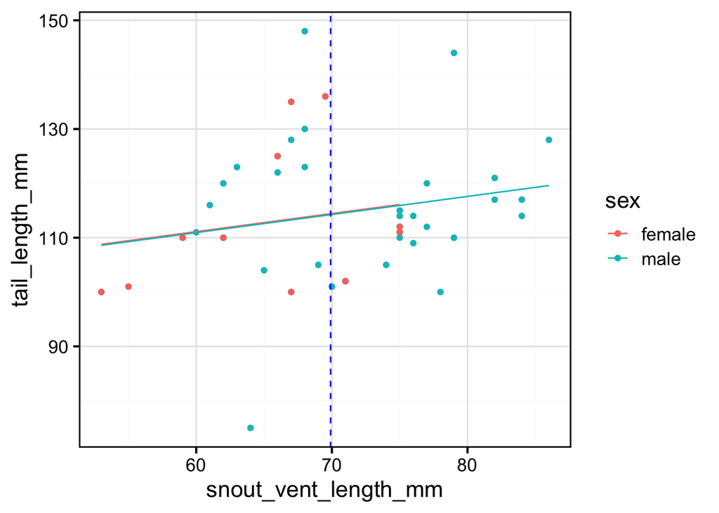

```r
#make ANCOVA from a fit model; one of many ways to do this.
model_1_fortified <- fortify(model_1)

ggplot(model_1) +
  geom_point(aes(x = snout_vent_length_mm, y = tail_length_mm, color = sex)) +
  geom_line(aes(x = snout_vent_length_mm, y = .fitted, color = sex)) +
  geom_vline(xintercept=mean(draco_bimaculatus$snout_vent_length_mm), linetype='dashed', color='blue', size=0.5) +
  theme_cmg() #this was my theme defined in a script
```

For tail length, the adjusted difference and P-value matches `gtsummary` output. There is not a noticeable difference in tail length between the sexes at the grand mean.

Notice also the technique for plotting an ANCOVA model using `fortify`. Open the `model_1_fortified` dataframe to see what a fortified dataset looks like; applies model calculations to the original dataset.

```r
summary(model_1)$coefficients["sexmale","Estimate"] #adjusted difference between marginal means
```

```
## [1] -0.173778
```

```r
summary(model_1)$coefficients["sexmale","Pr(>|t|)"] #p-value comparing adjusted means
```

```
## [1] 0.9708731
```

If more formatting is required, likely have to convert `gtsummary` object to a `gt` object and modify with `gt` package.

Other worked examples:

https://cran.r-project.org/web/packages/gtsummary/vignettes/gallery.html

https://www.pipinghotdata.com/posts/2021-07-14-polished-summary-tables-in-r-with-gtsummary/